# Research

Carol Bao

2024-08-02

# Introduction

Air pollution stems from various sources, including vehicle emissions, oil and natural gas combustion, chemical production fumes, forest fires, agricultural activities, construction, and more. The World Health Organization identifies particulate matter, carbon monoxide, ozone, nitrogen dioxide, and sulfur dioxide as pollutants of major public health concern. This research paper focuses on particulate matter (PM2.5), nitrogen dioxide (NO2), and sulfur dioxide (SO2).

While the amount of pollution and its effects on public health have been extensively studied, the influence of temperature and pollution variability has received insufficient attention. This study hypothesizes that increased variability in pollution and decreased temperatures are likely to elevate the risk of lung cancer, with a particular focus on the impact of air pollution on lung cancer in the United States.

Methodology Data I combined data from four different sources (air quality, cancer incidience, gazetter, weather). All of them were ordered by county, so I combined them through that. I did some variable engineering and ended up with variables about temperature, amount of air pollution, and variability in air pollution. Additional changes to the data had to be made: removing some sites from counties that had more than one site, removing sites that captured too large of an area, and hourly to monthly aggregation.

Machine learning PCA KMeans

XGBoost Tree-based methods like Random Forest and XGBoost can determine feature importance even with missing values. XGBoost is particularly suitable for handling large amounts of missing data and excels with larger datasets due to its efficiency and speed. In contrast, Random Forest can manage moderate amounts of missing data but may not perform as well with extensive gaps.

Multiple Imputation - lasso Since this dataset has many missing values, it would be unethical to remove every single datapoint that ijncludes a missing value (the table will shrink from 100k rows to 7k rows and that’s an inaccurate way of showing the data)

# Methodology

## Libraries

```r
library(odbc)
library(DBI)
library(dplyr)
```

```r
library(ggplot2)
library(skimr)
library(knitr)
library(kableExtra)
library(xgboost)
library(caret)
library(tidyverse)
library(missMDA)
library(FactoMineR)
library(factoextra)
library(stats)
library(cluster)
library(formattable)
library(magrittr)
library(mice)
library(conflicted)
library(glmnet)
```

## Data

### Sources

1. Air Quality Data
- **Source:** United States Environmental Protection Agency
- **Data Scope:** Daily data from 2010-2019, by county
- **Details:** Includes geographic identifier codes, dates and times, representative latitude and longitude coordinates, sample measurements (SO₂, NO₂, and PM₂.₅), method type, and more
- **Link:** [EPA Air Quality Data](https://aqs.epa.gov/aqsweb/airdata/download_files.html#Daily)
2. Cancer Incidence Data
- **Source:** National Cancer Institute
- **Data Scope:** By county, 2016-2020
- **Details:** Includes geographic identifier codes, cancer types, and the number of cases per 100,000 people
- **Link:** [Cancer Atlas Table View](https://gis.cancer.gov/canceratlas/tableview/)
3. The U.S. Gazetteer Files
- **Source:** US Census Bureau
- **Data Scope:** By County, 2023
- **Details:** Includes geographic identifier codes, area measurements, and representative latitude and longitude coordinates
- **Link:** [U.S. Gazetteer Files](https://www.census.gov/geographies/reference-files/time-series/geo/gazetteer-files.html)
4. Weather Data
- **Source:** UC Davis, Department of Agricultural and Resource Economics
- **Data Scope:** Hourly data from 2010-2019, by county
- **Details:** Includes maximum, minimum, and average temperature
- **Link:** [UC Davis Weather Data](https://asmith.ucdavis.edu/data/prism-weather)

### Feature Description

| Feature Name | Description |
| --- | --- |
| State Code | The FIPS code of the state |
| County Code | The FIPS code of the county |
| Site Num | A unique number within the county identifying the air pollution site |
| County FIPS | The FIPS code of the county |
| YYYY | Year |
| MM | Month |
| YYYYMM | Year and Month |
| MEDIAN_MAX_NO2 | The monthly median of the daily maximum value of NO2 in parts per billion |
| MEDIAN_MIN_NO2 | The monthly median of the daily minimum value of NO2 in parts per billion |
| MEDIAN_AVG_NO2 | The monthly median of the daily average value of NO2 in parts per billion |
| MEDIAN_MAX_SO2 | The monthly median of the daily maximum value of SO2 in parts per billion |
| MEDIAN_MIN_SO2 | The monthly median of the daily minimum value of SO2 in parts per billion |
| MEDIAN_AVG_SO2 | The monthly median of the daily average value of SO2 in parts per billion |
| MEDIAN_MAX_PM2.5 | The monthly median of the daily maximum value of PM2.5 in Micrograms/cubic meter (LC) |
| MEDIAN_MIN_PM2.5 | The monthly median of the daily minimum value of PM2.5 in Micrograms/cubic meter (LC) |
| MEDIAN_AVG_PM2.5 | The monthly median of the daily average value of PM2.5 in Micrograms/cubic meter (LC) |
| MEDIAN_AVG_MORNING_NO2 | The monthly median of the average value of NO2 from 7 AM to 6 PM in parts per billion |
| MEDIAN_AVG_MORNING_SO2 | The monthly median of the average value of SO2 from 7 AM to 6 PM in parts per billion |
| MEDIAN_AVG_MORNING_PM2.5 | The monthly median of the average value of PM2.5 from 7 AM to 6 PM in Micrograms/cubic meter (LC) |
| MEDIAN_AVG_NIGHT_NO2 | The monthly median of the average value of NO2 from 7 PM to 6 AM in parts per billion |
| MEDIAN_AVG_NIGHT_SO2 | The monthly median of the average value of SO2 from 7 PM to 6 AM in parts per billion |
| MEDIAN_AVG_NIGHT_PM2.5 | The monthly median of the average value of PM2.5 from 7 PM to 6 AM in Micrograms/cubic meter (LC) |
| median_tmin | The monthly median of the daily minimum temperature |
| median_tmax | The monthly median of the daily maximum temperature |
| median_tavg | The monthly median of the daily average temperature |
| All_Cancer_Sites | Number of all cancer cases from the years 2016 to 2020 adjusted rate per 100,000 |
| Lung_&_Bronchus | Number of lung and bronchus cancer cases from the years 2016 to 2020 adjusted rate per 100,000 |
| Thyroid | Number of thyroid cancer cases from the years 2016 to 2020 adjusted rate per 100,000 |
| MEDIAN_DIFF_MAX_MIN_NO2 | The monthly median of the difference between the daily maximum value of NO2 and the daily minimum value of NO2 in parts per billion. |
| MEDIAN_DIFF_MAX_MIN_SO2 | The monthly median of the difference between the daily maximum value of SO2 and the daily minimum value of SO2 in parts per billion. |
| MEDIAN_DIFF_MAX_MIN_PM2.5 | The monthly median of the difference between the daily maximum value of PM2.5 and the daily minimum value of PM2.5 in micrograms/cubic meter (LC). |
| MEDIAN_DIFF_PM_AM_NO2 | The monthly median of the difference between the average value of NO2 from 7 AM to 6 PM and the average value of NO2 from 7 PM to 6 AM in parts per billion. |
| MEDIAN_DIFF_PM_AM_SO2 | The monthly median of the difference between the average value of SO2 from 7 AM to 6 PM and the average value of SO2 from 7 PM to 6 AM in parts per billion. |
| MEDIAN_DIFF_PM_AM_PM2.5 | The monthly median of the difference between the average value of PM2.5 from 7 AM to 6 PM and the average value of PM2.5 from 7 PM to 6 AM in micrograms/cubic meter (LC). |

### Processing

#### SQL Flow Chart

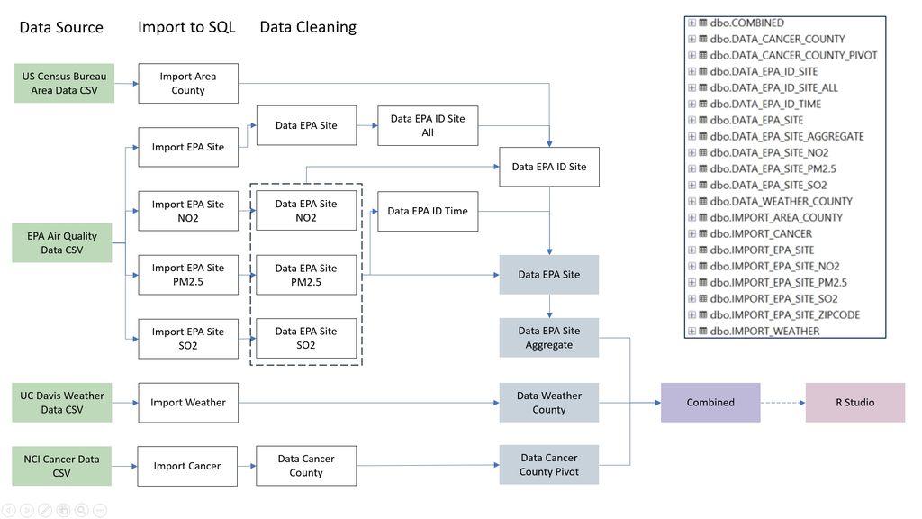

#### MDL

Some sites had multiple sensors, each recording different pollution levels. This led to having several readings for the same location. Each reading also had an associated MDL (Method Detection Limit). According to the EPA, the MDL is “the minimum sample concentration detectable by the monitor and method. Note: if samples are reported below this level, they may have been replaced by half the MDL.”

To ensure accuracy and reduce the chance of false values, we selected the output with the lowest MDL. Below is the query used to rank the MDLs and select the smallest one:

```r
UPDATE A
SET
A.[Sample Measurement NO2]=B.[Sample Measurement],
A.[Units of Measure NO2]=B.[Units of Measure],
A.[MDL NO2]=B.[MDL]
FROM [dbo].[DATA_EPA_SITE] A
LEFT OUTER JOIN
(SELECT [State Code],[County Code],[Site Num],[Date Local],[Time Local],[Sample Measurement],[Units of Measure],[MDL]
,RANK() OVER(PARTITION BY [State Code],[County Code],[Site Num],[Date Local],[Time Local] ORDER BY [MDL]) RK
FROM [dbo].[DATA_EPA_SITE_NO2]) B
ON A.[State Code]=B.[State Code]
AND A.[County Code]=B.[County Code]
AND A.[Site Num]=B.[Site Num]
AND A.[Date Local]=B.[Date Local]
AND A.[Time Local]=B.[Time Local]
AND B.RK=1

UPDATE A
SET
A.[Sample Measurement SO2]=C.[Sample Measurement],
A.[Units of Measure SO2]=C.[Units of Measure],
A.[MDL SO2]=C.[MDL]
FROM [dbo].[DATA_EPA_SITE] A
LEFT OUTER JOIN
(SELECT [State Code],[County Code],[Site Num],[Date Local],[Time Local],[Sample Measurement],[Units of Measure],[MDL]
,RANK() OVER(PARTITION BY [State Code],[County Code],[Site Num],[Date Local],[Time Local] ORDER BY [MDL]) RK
FROM [dbo].[DATA_EPA_SITE_SO2]) C
ON A.[State Code]=C.[State Code]
AND A.[County Code]=C.[County Code]
AND A.[Site Num]=C.[Site Num]
AND A.[Date Local]=C.[Date Local]
AND A.[Time Local]=C.[Time Local]
AND C.RK=1

UPDATE A
SET
A.[Sample Measurement PM2.5]=D.[Sample Measurement],
A.[Units of Measure PM2.5]=D.[Units of Measure],
A.[MDL PM2.5]=D.[MDL]
FROM [dbo].[DATA_EPA_SITE] A
LEFT OUTER JOIN
(SELECT [State Code],[County Code],[Site Num],[Date Local],[Time Local],[Sample Measurement],[Units of Measure],[MDL]
,RANK() OVER(PARTITION BY [State Code],[County Code],[Site Num],[Date Local],[Time Local] ORDER BY [MDL]) RK
FROM [dbo].[DATA_EPA_SITE_PM2.5]) D
ON A.[State Code]=D.[State Code]
AND A.[County Code]=D.[County Code]
AND A.[Site Num]=D.[Site Num]
AND A.[Date Local]=D.[Date Local]
AND A.[Time Local]=D.[Time Local]
AND D.RK=1

DELETE FROM [dbo].[DATA_EPA_SITE] WHERE [Sample Measurement NO2] is null and [Sample Measurement SO2] is null  and [Sample Measurement PM2.5] is null
```

#### Area

Large counties with fewer monitoring sites may not accurately represent air pollution levels. To identify outliers, the ratio of county size to the number of sites in each county was calculated. The 90th percentile was used as the cutoff point for identifying outliers because it is a common threshold, and it aligned well with the data when plotted on a graph.

Below is the query used to perform this analysis:

```r
UPDATE X
SET X.[Area Per Site]=Y.[Area_Per_Site],[Area Cutoff]=[Area_Cutoff]
FROM [dbo].[DATA_EPA_ID_SITE] X
LEFT OUTER JOIN
(SELECT A.[County FIPS]
,[ALAND_SQMI]/[Number of Sites][Area_Per_Site]
,PERCENTILE_CONT(0.90) WITHIN GROUP (ORDER BY [ALAND_SQMI]/[Number of Sites]) OVER () [Area_Cutoff]
FROM
(SELECT [County FIPS]
,COUNT ([Site Num])[Number of Sites]
FROM [dbo].[DATA_EPA_ID_SITE]
GROUP BY [County FIPS]) A
JOIN
(SELECT [ALAND_SQMI],[GEOID] FROM [dbo].[IMPORT_AREA_COUNTY]) B
ON A.[County FIPS]=B.[GEOID]
) Y
ON X.[County FIPS]=Y.[County FIPS]
```

#### Hourly to Monthly Aggregation

The data was aggregated from hourly to monthly intervals to enable easier management and analysis. First, the hourly data was combined into daily data by calculating the daily maximums, minimums, and averages, along with the average pollution levels during daytime and nighttime. The differences between the maximum and minimum values and between the daytime and nighttime values were also computed to show variability. The data was then further aggregated to a monthly level, which helps in capturing general daily trends over a longer period.

Below is the query used to perform these tasks.

```r
TRUNCATE TABLE [dbo].[DATA_EPA_SITE_AGGREGATE]
INSERT INTO [dbo].[DATA_EPA_SITE_AGGREGATE]
SELECT DISTINCT
[State Name],[County Name],A.[State Code],A.[County Code],A.[Site Num]
,[Latitude],[Longitude],[Zip Code]
,[Cancer State Name],[Cancer County Name],[County FIPS]
,[YYYY],[MM],[YYYYMM]
,PERCENTILE_CONT(0.50) WITHIN GROUP (ORDER BY [MAX_NO2]) OVER (PARTITION BY A.[State Code],A.[County Code],A.[Site Num],A.[YYYYMM]) AS [MEDIAN_MAX_NO2]
,PERCENTILE_CONT(0.50) WITHIN GROUP (ORDER BY [MIN_NO2]) OVER (PARTITION BY A.[State Code],A.[County Code],A.[Site Num],A.[YYYYMM]) AS [MEDIAN_MIN_NO2]
,PERCENTILE_CONT(0.50) WITHIN GROUP (ORDER BY [AVG_NO2]) OVER (PARTITION BY A.[State Code],A.[County Code],A.[Site Num],A.[YYYYMM]) AS [MEDIAN_AVG_NO2]
,PERCENTILE_CONT(0.50) WITHIN GROUP (ORDER BY [MAX_SO2]) OVER (PARTITION BY A.[State Code],A.[County Code],A.[Site Num],A.[YYYYMM]) AS [MEDIAN_MAX_SO2]
,PERCENTILE_CONT(0.50) WITHIN GROUP (ORDER BY [MIN_SO2]) OVER (PARTITION BY A.[State Code],A.[County Code],A.[Site Num],A.[YYYYMM]) AS [MEDIAN_MIN_SO2]
,PERCENTILE_CONT(0.50) WITHIN GROUP (ORDER BY [AVG_SO2]) OVER (PARTITION BY A.[State Code],A.[County Code],A.[Site Num],A.[YYYYMM]) AS [MEDIAN_AVG_SO2]
,PERCENTILE_CONT(0.50) WITHIN GROUP (ORDER BY [MAX_PM2.5]) OVER (PARTITION BY A.[State Code],A.[County Code],A.[Site Num],A.[YYYYMM]) AS [MEDIAN_MAX_PM2.5]
,PERCENTILE_CONT(0.50) WITHIN GROUP (ORDER BY [MIN_PM2.5]) OVER (PARTITION BY A.[State Code],A.[County Code],A.[Site Num],A.[YYYYMM]) AS [MEDIAN_MIN_PM2.5]
,PERCENTILE_CONT(0.50) WITHIN GROUP (ORDER BY [AVG_PM2.5]) OVER (PARTITION BY A.[State Code],A.[County Code],A.[Site Num],A.[YYYYMM]) AS [MEDIAN_AVG_PM2.5]

,PERCENTILE_CONT(0.50) WITHIN GROUP (ORDER BY [AVG_MORNING_NO2]) OVER (PARTITION BY A.[State Code],A.[County Code],A.[Site Num],A.[YYYYMM]) AS [MEDIAN_AVG_MORNING_NO2]
,PERCENTILE_CONT(0.50) WITHIN GROUP (ORDER BY [AVG_MORNING_SO2]) OVER (PARTITION BY A.[State Code],A.[County Code],A.[Site Num],A.[YYYYMM]) AS [MEDIAN_AVG_MORNING_SO2]
,PERCENTILE_CONT(0.50) WITHIN GROUP (ORDER BY [AVG_MORNING_PM2.5]) OVER (PARTITION BY A.[State Code],A.[County Code],A.[Site Num],A.[YYYYMM]) AS [MEDIAN_AVG_MORNING_PM2.5]
,PERCENTILE_CONT(0.50) WITHIN GROUP (ORDER BY [AVG_NIGHT_NO2]) OVER (PARTITION BY A.[State Code],A.[County Code],A.[Site Num],A.[YYYYMM]) AS [MEDIAN_AVG_NIGHT_NO2]
,PERCENTILE_CONT(0.50) WITHIN GROUP (ORDER BY [AVG_NIGHT_SO2]) OVER (PARTITION BY A.[State Code],A.[County Code],A.[Site Num],A.[YYYYMM]) AS [MEDIAN_AVG_NIGHT_SO2]
,PERCENTILE_CONT(0.50) WITHIN GROUP (ORDER BY [AVG_NIGHT_PM2.5]) OVER (PARTITION BY A.[State Code],A.[County Code],A.[Site Num],A.[YYYYMM]) AS [MEDIAN_AVG_NIGHT_PM2.5]

,PERCENTILE_CONT(0.50) WITHIN GROUP (ORDER BY [MAX_NO2]-[MIN_NO2]) OVER (PARTITION BY A.[State Code],A.[County Code],A.[Site Num],A.[YYYYMM]) AS [MEDIAN_DIFF_MAX_MIN_NO2]
,PERCENTILE_CONT(0.50) WITHIN GROUP (ORDER BY [MAX_SO2]-[MIN_SO2]) OVER (PARTITION BY A.[State Code],A.[County Code],A.[Site Num],A.[YYYYMM]) AS [MEDIAN_DIFF_MAX_MIN_SO2]
,PERCENTILE_CONT(0.50) WITHIN GROUP (ORDER BY [MAX_PM2.5]-[MIN_PM2.5]) OVER (PARTITION BY A.[State Code],A.[County Code],A.[Site Num],A.[YYYYMM]) AS [MEDIAN_DIFF_MAX_MIN_PM2.5]

,PERCENTILE_CONT(0.50) WITHIN GROUP (ORDER BY [AVG_NIGHT_NO2]-[AVG_MORNING_NO2]) OVER (PARTITION BY A.[State Code],A.[County Code],A.[Site Num],A.[YYYYMM]) AS [MEDIAN_DIFF_PM_AM_NO2]
,PERCENTILE_CONT(0.50) WITHIN GROUP (ORDER BY [AVG_NIGHT_SO2]-[AVG_MORNING_SO2]) OVER (PARTITION BY A.[State Code],A.[County Code],A.[Site Num],A.[YYYYMM]) AS [MEDIAN_DIFF_PM_AM_SO2]
,PERCENTILE_CONT(0.50) WITHIN GROUP (ORDER BY [AVG_NIGHT_PM2.5]-[AVG_MORNING_PM2.5]) OVER (PARTITION BY A.[State Code],A.[County Code],A.[Site Num],A.[YYYYMM]) AS [MEDIAN_DIFF_PM_AM_PM2.5]
--INTO [dbo].[DATA_EPA_SITE_AGGREGATE]

FROM
(SELECT [State Name],[County Name],[State Code],[County Code],[Site Num]
,[Latitude],[Longitude],[Zip Code]
,[Cancer State Name],[Cancer County Name],[County FIPS]
,[Date Local],[YYYY],[MM],[YYYYMM]
,MAX ([Sample Measurement NO2])[MAX_NO2]
,MIN ([Sample Measurement NO2])[MIN_NO2]
,AVG ([Sample Measurement NO2])[AVG_NO2]
,MAX ([Sample Measurement SO2])[MAX_SO2]
,MIN ([Sample Measurement SO2])[MIN_SO2]
,AVG ([Sample Measurement SO2])[AVG_SO2]
,MAX ([Sample Measurement PM2.5])[MAX_PM2.5]
,MIN ([Sample Measurement PM2.5])[MIN_PM2.5]
,AVG ([Sample Measurement PM2.5])[AVG_PM2.5]
FROM [research].[dbo].[DATA_EPA_SITE]
GROUP BY [State Name],[County Name],[State Code],[County Code],[Site Num]
,[Latitude],[Longitude],[Zip Code]
,[Cancer State Name],[Cancer County Name],[County FIPS]
,[Date Local],[YYYY],[MM],[YYYYMM])A

LEFT OUTER JOIN
(SELECT [State Code],[County Code],[Site Num],[Date Local]
,AVG ([Sample Measurement NO2])[AVG_MORNING_NO2]
,AVG ([Sample Measurement SO2])[AVG_MORNING_SO2]
,AVG ([Sample Measurement PM2.5])[AVG_MORNING_PM2.5]
FROM [research].[dbo].[DATA_EPA_SITE]
WHERE [Time Local] in (8,9,10,11,12,13,14,15,16,17)
GROUP BY [State Code],[County Code],[Site Num],[Date Local])B
ON A.[State Code]=B.[State Code]
AND A.[County Code]=B.[County Code]
AND A.[Site Num]=B.[Site Num]
AND A.[Date Local]=B.[Date Local]

LEFT OUTER JOIN
(SELECT [State Code],[County Code],[Site Num],[Date Local]
,AVG ([Sample Measurement NO2])[AVG_NIGHT_NO2]
,AVG ([Sample Measurement SO2])[AVG_NIGHT_SO2]
,AVG ([Sample Measurement PM2.5])[AVG_NIGHT_PM2.5]
FROM [research].[dbo].[DATA_EPA_SITE]
WHERE [Time Local] in (20,21,22,23,0,1,2,3,4,5)
GROUP BY [State Code],[County Code],[Site Num],[Date Local])C
ON A.[State Code]=C.[State Code]
AND A.[County Code]=C.[County Code]
AND A.[Site Num]=C.[Site Num]
AND A.[Date Local]=C.[Date Local]
```

### Import Data

```r
# Establish connection
con <- dbConnect(odbc::odbc(),
                 Driver   = "ODBC Driver 17 for SQL Server",
                 Server   = "localhost",
                 Database = "research",
                 Port     = 1433,
                 Trusted_Connection = "Yes")


# Query the data
query <- "SELECT * FROM COMBINED"
data <- dbGetQuery(con, query)

# Close the connection
dbDisconnect(con)

# Rename Columns
data <- data %>% rename(Lung_And_Bronchus = `Lung_&_Bronchus`)

# View the first few rows of the data
str(data)

# Remove Columns
data <- data %>% select(-`State Name`,-`County Name`,-`State Code`,-`County Code`,-`Site Num`,-`Zip Code`,-`Cancer State Name`,-`Cancer County Name`,-`Latitude`,-`Longitude`,-`County FIPS`,
                        -`YYYY`,-`MM`,-`YYYYMM`,-`All_Cancer_Sites`,-`Thyroid`)
# Summary
summary(data)
```

### Exploratory Data Analysis (EDA)

```r
# Calculate the number of missing values for each column
missing_values <- data %>%
  summarise_all(~sum(is.na(.)))

# Calculate the total number of values for each column
total_values <- nrow(data)

# Calculate the percentage of missing values
missing_percentage <- missing_values / total_values * 100

# Combine the results into a data frame
missing_summary <- data.frame(
  Feature = names(data),
  Missing_Values = as.numeric(missing_values),
  Missing_Percentage = round(as.numeric(missing_percentage), 2)
)

# Display the table
kable(missing_summary, col.names = c("Feature", "Missing Values", "Missing Percentage (%)"),
      caption = "Summary of Missing Values and Percentages per Feature") %>%
  kable_styling(bootstrap_options = c("striped", "hover", "condensed"))
```

[output not shown]

```r
# Graph Data
for (feature in names(data)) {
  # Check if the feature is numeric
  if (is.numeric(data[[feature]])) {
    # Create a histogram for the current feature
    p <- ggplot(data, aes(x = .data[[feature]])) +
      geom_histogram(binwidth = 1, fill = "blue", color = "black") +
      labs(title = paste("Histogram of", feature), x = feature, y = "Frequency") +
      theme_minimal()

    # Print the plot
    print(p)
  }
}
```

## Machine Learning

### Principal Component Analysis

This data does not contain Lung cancer data or null values.

```r
# Establish connection
con <- dbConnect(odbc::odbc(),
                 Driver   = "ODBC Driver 17 for SQL Server",
                 Server   = "localhost",
                 Database = "research",
                 Port     = 1433,
                 Trusted_Connection = "Yes")


# Query the data
query <- "SELECT
[MEDIAN_MAX_NO2]
,[MEDIAN_MIN_NO2]
,[MEDIAN_AVG_NO2]
,[MEDIAN_MAX_SO2]
,[MEDIAN_MIN_SO2]
,[MEDIAN_AVG_SO2]
,[MEDIAN_MAX_PM2.5]
,[MEDIAN_MIN_PM2.5]
,[MEDIAN_AVG_PM2.5]
,[MEDIAN_AVG_MORNING_NO2]
,[MEDIAN_AVG_MORNING_SO2]
,[MEDIAN_AVG_MORNING_PM2.5]
,[MEDIAN_AVG_NIGHT_NO2]
,[MEDIAN_AVG_NIGHT_SO2]
,[MEDIAN_AVG_NIGHT_PM2.5]
,[MEDIAN_DIFF_MAX_MIN_NO2]
,[MEDIAN_DIFF_MAX_MIN_SO2]
,[MEDIAN_DIFF_MAX_MIN_PM2.5]
,[MEDIAN_DIFF_PM_AM_NO2]
,[MEDIAN_DIFF_PM_AM_SO2]
,[MEDIAN_DIFF_PM_AM_PM2.5]
,[median_tmin]
,[median_tmax]
,[median_tavg]
FROM [dbo].[COMBINED]
WHERE [MEDIAN_DIFF_PM_AM_NO2] IS NOT NULL AND  [MEDIAN_DIFF_PM_AM_SO2] IS NOT NULL AND [MEDIAN_DIFF_PM_AM_PM2.5] IS NOT NULL AND [median_tmin] IS NOT NULL
"
data_PCA <- dbGetQuery(con, query)

# Close the connection
dbDisconnect(con)


# View the first few rows of the data
str(data_PCA)
```

```r
# Perform PCA
pca_res <- PCA(data_PCA, scale.unit = TRUE, ncp = 8, graph = FALSE)

# Summary of PCA results
summary(pca_res)



# Visualize the eigenvalues (scree plot)
fviz_eig(pca_res, addlabels = TRUE, ylim = c(0, 50))




# Extract variable contributions
contrib <- get_pca_var(pca_res)$contrib

# Convert to a data frame for better readability
contrib_df <- as.data.frame(contrib)

# Add feature names as row names
rownames(contrib_df) <- colnames(data_PCA)

# Display the table
print(contrib_df)



# Contributions of variables to PC1
fviz_contrib(pca_res, choice = "var", axes = 1)
fviz_contrib(pca_res, choice = "var", axes = 2)
fviz_contrib(pca_res, choice = "var", axes = 3)
fviz_contrib(pca_res, choice = "var", axes = 4)
fviz_contrib(pca_res, choice = "var", axes = 5)
fviz_contrib(pca_res, choice = "var", axes = 6)
fviz_contrib(pca_res, choice = "var", axes = 7)
fviz_contrib(pca_res, choice = "var", axes = 8)
```

[output not shown]

The dimensions (Dim.1, Dim.2, etc.) correspond to the principal components identified by PCA. PCA generally aims to reduce the dimensionality of data while preserving as much variance as possible. Each variable (e.g., MEDIAN_MAX_NO2, MEDIAN_AVG_SO2) shows its contribution to the respective principal component. A variable with a high value significantly influences that component.

THis is not a good method because the dimensions are redundant with the clusters I artificially created beforehand. THe dimensions sorted the variables into NO2, SO2, temperature, and variability, which is already obvious given the dataset. In addition, my goal isn’t to reduce dimeinsionality so I really have no idea why I used it.